# Rcourse

## Data Analysis with R.

The development of new and more performing technologies goes hand in a hand with the increasing availability of data (often of different origins), which requires the development and use of up-to-date analytic and statistical tools.

In this context, the knowledge of adequate programming languages becomes essential. Specifically, the R-language and working environment represents one of the most used and effective tools in many scientific disciplines, allowing the management and analysis of data. R is a free, multi-platform language distributed under the GNU GPL license (Unix, Linux, Mac OS X, Windows).

This course aims to introduce the basics of data analysis in ecology, by exploiting the potential offered by the R programming language. The course is structured in two phases, basic and advanced, each of which divided into four modules of two hours each, combining theoretical topics with numerical exercises aimed at familiarizing yourself with the R work environment.

## The (general) program

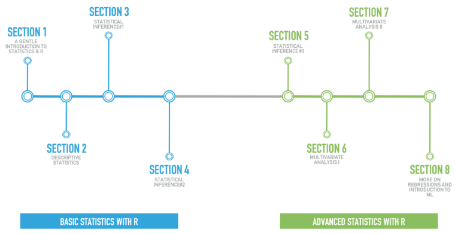

### Basic statistics with R

**A (non-exhaustive) list of topics**

Introduction to R; How to download and install R; Panels and toolbars; Data acquisition; Use of help and search for commands; How to write and run a script; Notes on packages; Pre-processing data; How to manage data distribution; Data normalization/standardization; Central tendency; Variability in data distribution; Measures of variability; Measures of symmetry; Understanding confidence interval; Statistical inference defined; Hypothesis testing; P-value; Errors in inference; Statistical power; Effect size; Independent and paired values; Parametric statistics; One-sample t-test; Two-sample t-test; One-way ANOVA; One-way ANOVA w/blocks; One-way ANOVA w/random blocks; Two-way ANOVA; Repeated measure ANOVA; Correlation and linear regression; Model assumption

### Advanced statistics with R

**A (non-exhaustive) list of topics**

Nonparametric Tests; One-sample Wilcoxon Signed-rank Test; Sign Test for One-sample Data; Two-sample Mann–Whitney U Test; Mood’s Median; Test for Two-sample Data; Two-sample Paired Signed-rank Test; Sign Test for Two-sample Paired Data; Kruskal–Wallis Test; Friedman Test; Aligned Ranks Transformation ANOVA; Multivariate analysis; Clustering Ordination; Nonparametric Regression; Permutation Tests; Introduction to Linear Models; Random Effects; Generalized Linear Models; Generalized Additive Models; Model selection

# Slides, scripts and data

## Download options

The easiest way is to download all the material as a zipped file.

[Download.zip](https://github.com/brunobellisario/Rcourse/archive/refs/heads/main.zip)

This option will download the entire course material (R Base & R Advanced).

If you do not want to download everything (I can understand!), you can navigate to the Scripts and Slides folders, and download (right click -> download as) only the files related to the version of the course you are interested in (base or advanced).

**Rcourse base**

[slides.pdf](https://github.com/brunobellisario/Rcourse/tree/main/Slides/Base/PDF)

[slides.ppt](https://github.com/brunobellisario/Rcourse/tree/main/Slides/Base/PowerPoint)

[scripts & datasets](https://github.com/brunobellisario/Rcourse/tree/main/R_scripts/Base)

**Rcourse advanced**

[slides.pdf](https://github.com/brunobellisario/Rcourse/tree/main/Slides/Advanced/PDF)

[slides.ppt](https://github.com/brunobellisario/Rcourse/tree/main/Slides/Advanced/PowerPoint)

[scripts & datasets](https://github.com/brunobellisario/Rcourse/tree/main/R_scripts/Advanced)

# Marine ecology computational training

Here you can find a series of resources developed specifically for an overview of R uses in marine ecology.

## Download options

Please, download all the material as a zipped file.

[Download.zip](https://drive.google.com/file/d/1kTtw3MUb8_InlZKdGNFmM6WF6KKgT8_Z/view?usp=sharing)

# Installing R and RStudio

To get started with R, you need to acquire your own copy. This appendix will show you how to download R as well as RStudio, a software application that makes R easier to use. Both R and RStudio are free and easy to download.

# How to Download and Install R

R is maintained by an international team of developers who make the language available through the web page of [The Comprehensive R Archive Network](https://cran.r-project.org/). The top of the web page provides three links for downloading R. Follow the link that describes your operating system: Windows, Mac, or Linux.

# Windows

To install R on Windows, click the “Download R for Windows” link. Then click the “base” link. Next, click the first link at the top of the new page. This link should say something like “Download R 3.0.3 for Windows,” except the 3.0.3 will be replaced by the most current version of R. The link downloads an installer program, which installs the most up-to-date version of R for Windows. Run this program and step through the installation wizard that appears. The wizard will install R into your program files folders and place a shortcut in your Start menu. Note that you’ll need to have all of the appropriate administration privileges to install new software on your machine.

# Mac

To install R on a Mac, click the “Download R for Mac” link. Next, click on the R-3.0.3 package link (or the package link for the most current release of R). An installer will download to guide you through the installation process, which is very easy. The installer lets you customize your installation, but the defaults will be suitable for most users. I’ve never found a reason to change them. If your computer requires a password before installing new programs, you’ll need it here.

# Linux

R comes pre-installed on many Linux systems, but you’ll want the newest version of R if yours is out of date. The CRAN website provides files to build R from source on Debian, Redhat, SUSE, and Ubuntu systems under the link “Download R for Linux.” Click the link and then follow the directory trail to the version of Linux you wish to install on. The exact installation procedure will vary depending on the Linux system you use. CRAN guides the process by grouping each set of source files with documentation or README files that explain how to install on your system.

# RStudio

RStudio is an Integrated Development Environment (IDE) for R, a programming language for statistical computing and graphics. It is available in two formats: RStudio Desktop is a regular desktop application while RStudio Server runs on a remote server and allows accessing RStudio using a web browser. You can download it for free [here](https://www.rstudio.com/products/rstudio/download/#download). Scroll down and choose the installer that fits your OS.

# Useful info

Please, remember that for the use of RStudio is **MANDATORY** to have R first installed on your PC.